# Laboratorio 3: Técnicas de Reducción de la Dimensionalidad

Minería de Datos - Grado en Matemáticas

# Introducción

En este laboratorio trabajaremos con técnicas de reducción de la dimensionalidad, centrándonos en:

- **Selección de variables** (Filter, Wrapper)
- **Análisis de Componentes Principales (PCA)**
- **Escalado Multidimensional (MDS)**

## Objetivos del laboratorio

1. Comprender cuándo y por qué aplicar técnicas de reducción de dimensionalidad
2. Implementar métodos de selección de variables
3. Aplicar PCA y interpretar sus resultados
4. Visualizar datos de alta dimensión en 2D/3D
5. Comparar diferentes técnicas de reducción de dimensionalidad

# Configuración inicial

```r
# Librerías necesarias
library(tidyverse)
library(corrplot)
library(FactoMineR)
library(factoextra)
library(caret)
library(MASS)

# Configuración de gráficos
theme_set(theme_minimal())
```

# Parte 1: Selección de Variables

## 1.1 Métodos Filter

Los métodos **filter** son independientes del modelo y evalúan la relevancia de las variables usando medidas estadísticas.

### Ejercicio 1.1: Correlación de Pearson

**Objetivo**: Identificar variables altamente correlacionadas en el dataset `mtcars`.

```r
# Cargar datos
data(mtcars)
head(mtcars)
```

```
                   mpg cyl disp  hp drat    wt  qsec vs am gear carb
Mazda RX4         21.0   6  160 110 3.90 2.620 16.46  0  1    4    4
Mazda RX4 Wag     21.0   6  160 110 3.90 2.875 17.02  0  1    4    4
Datsun 710        22.8   4  108  93 3.85 2.320 18.61  1  1    4    1
Hornet 4 Drive    21.4   6  258 110 3.08 3.215 19.44  1  0    3    1
Hornet Sportabout 18.7   8  360 175 3.15 3.440 17.02  0  0    3    2
Valiant           18.1   6  225 105 2.76 3.460 20.22  1  0    3    1
```

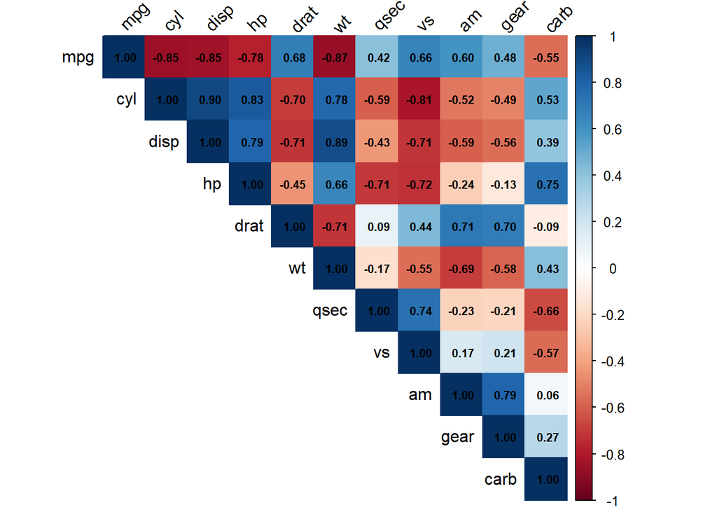

```r
# Calcular matriz de correlación
cor_matrix <- cor(mtcars)

# Visualizar correlaciones
corrplot(cor_matrix, method = "color", type = "upper",
         tl.col = "black", tl.srt = 45,
         addCoef.col = "black", number.cex = 0.7)
```

```r
# Identificar variables altamente correlacionadas (|r| > 0.8)
high_cor <- which(abs(cor_matrix) > 0.8 & abs(cor_matrix) < 1, arr.ind = TRUE)
high_cor_pairs <- unique(t(apply(high_cor, 1, sort)))
rownames(high_cor_pairs) <- NULL
colnames(high_cor_pairs) <- c("Var1", "Var2")

print("Variables altamente correlacionadas:")
```

```
[1] "Variables altamente correlacionadas:"
```

```r
for(i in 1:nrow(high_cor_pairs)) {
  v1 <- high_cor_pairs[i, 1]
  v2 <- high_cor_pairs[i, 2]
  cat(sprintf("%s - %s: r = %.3f\n",
              colnames(mtcars)[v1],
              colnames(mtcars)[v2],
              cor_matrix[v1, v2]))
}
```

```
mpg - cyl: r = -0.852
mpg - disp: r = -0.848
mpg - wt: r = -0.868
cyl - disp: r = 0.902
cyl - hp: r = 0.832
cyl - vs: r = -0.811
disp - wt: r = 0.888
```

**Pregunta**: ¿Qué variables eliminarías para reducir la multicolinealidad?

### Ejercicio 1.2: Test Chi-cuadrado

**Objetivo**: Seleccionar las mejores variables categóricas usando el test Chi-cuadrado.

```r
# Crear datos categóricos
set.seed(123)
iris_discrete <- iris
iris_discrete$Sepal.Length.cat <- cut(iris$Sepal.Length, breaks = 3,
                                      labels = c("Bajo", "Medio", "Alto"))
iris_discrete$Sepal.Width.cat <- cut(iris$Sepal.Width, breaks = 3,
                                     labels = c("Bajo", "Medio", "Alto"))
iris_discrete$Petal.Length.cat <- cut(iris$Petal.Length, breaks = 3,
                                      labels = c("Bajo", "Medio", "Alto"))
iris_discrete$Petal.Width.cat <- cut(iris$Petal.Width, breaks = 3,
                                     labels = c("Bajo", "Medio", "Alto"))

# Test Chi-cuadrado para cada variable
chi_scores <- sapply(iris_discrete[, 6:9], function(x) {
  chisq.test(table(x, iris_discrete$Species))$statistic
})

# Ordenar por importancia
chi_scores_sorted <- sort(chi_scores, decreasing = TRUE)
print("Importancia de variables (Chi-cuadrado):")
```

```
[1] "Importancia de variables (Chi-cuadrado):"
```

```r
print(chi_scores_sorted)
```

```
 Petal.Width.cat.X-squared Petal.Length.cat.X-squared
                 266.90821                  256.52174
Sepal.Length.cat.X-squared  Sepal.Width.cat.X-squared
                 111.63387                   45.12466
```

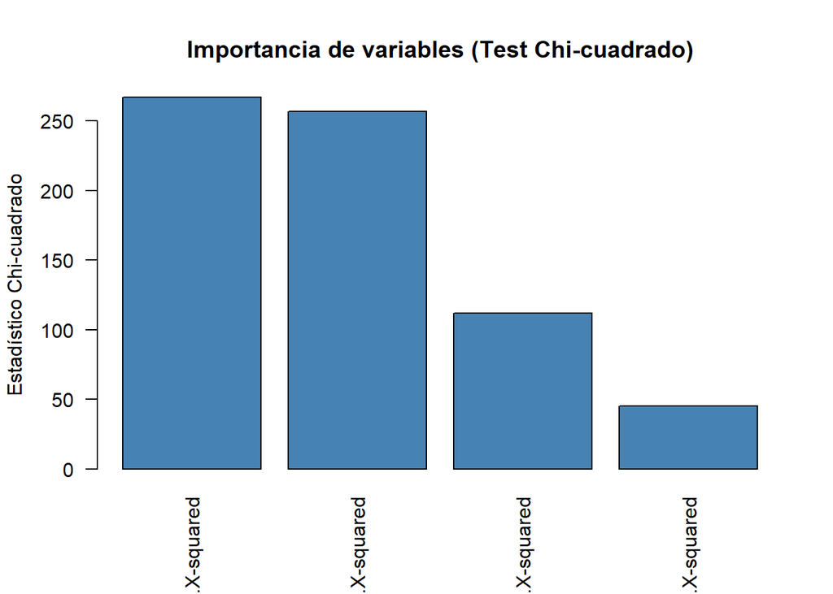

```r
# Visualizar
barplot(chi_scores_sorted, las = 2, col = "steelblue",
        main = "Importancia de variables (Test Chi-cuadrado)",
        ylab = "Estadístico Chi-cuadrado")
```

## 1.2 Métodos Wrapper

Los métodos **wrapper** usan modelos de ML para evaluar subconjuntos de variables.

### Ejercicio 1.3: Forward Selection

```r
# Datos
data(mtcars)

# Forward selection usando step()
# Modelo nulo (sin predictores)
null_model <- lm(mpg ~ 1, data = mtcars)

# Modelo completo
full_model <- lm(mpg ~ ., data = mtcars)

# Forward selection
forward_model <- step(null_model,
                     scope = list(lower = null_model, upper = full_model),
                     direction = "forward",
                     trace = 0)

print("Variables seleccionadas (Forward Selection):")
```

```
[1] "Variables seleccionadas (Forward Selection):"
```

```r
print(summary(forward_model)$coefficients)
```

```
              Estimate Std. Error   t value     Pr(>|t|)
(Intercept) 38.7517874 1.78686403 21.687038 4.799399e-19
wt          -3.1669731 0.74057588 -4.276365 1.994765e-04
cyl         -0.9416168 0.55091638 -1.709183 9.848010e-02
hp          -0.0180381 0.01187625 -1.518838 1.400152e-01
```

```r
cat("\nR² del modelo:", summary(forward_model)$r.squared, "\n")
```

```
R² del modelo: 0.84315
```

```r
cat("R² ajustado:", summary(forward_model)$adj.r.squared, "\n")
```

```
R² ajustado: 0.8263446
```

### Ejercicio 1.4: Backward Elimination

```r
# Backward elimination
backward_model <- step(full_model,
                      direction = "backward",
                      trace = 0)

print("Variables seleccionadas (Backward Elimination):")
```

```
[1] "Variables seleccionadas (Backward Elimination):"
```

```r
print(summary(backward_model)$coefficients)
```

```
             Estimate Std. Error   t value     Pr(>|t|)
(Intercept)  9.617781  6.9595930  1.381946 1.779152e-01
wt          -3.916504  0.7112016 -5.506882 6.952711e-06
qsec         1.225886  0.2886696  4.246676 2.161737e-04
am           2.935837  1.4109045  2.080819 4.671551e-02
```

```r
cat("\nR² del modelo:", summary(backward_model)$r.squared, "\n")
```

```
R² del modelo: 0.8496636
```

```r
cat("R² ajustado:", summary(backward_model)$adj.r.squared, "\n")
```

```
R² ajustado: 0.8335561
```

**Pregunta**: ¿Coinciden las variables seleccionadas por forward selection y backward elimination?

# Parte 2: Análisis de Componentes Principales (PCA)

## 2.1 PCA: Fundamentos

### Ejercicio 2.1: PCA paso a paso

**Objetivo**: Calcular PCA manualmente para comprender el proceso matemático completo.

```r
# Datos (primeras 4 variables de iris)
data(iris)
X <- iris[, 1:4]

cat("=== ANÁLISIS DE COMPONENTES PRINCIPALES: PASO A PASO ===\n\n")
```

```
=== ANÁLISIS DE COMPONENTES PRINCIPALES: PASO A PASO ===
```

```r
# Paso 0: Exploración inicial
cat("PASO 0: Datos originales\n")
```

```
PASO 0: Datos originales
```

```r
cat("Dimensiones:", nrow(X), "observaciones x", ncol(X), "variables\n")
```

```
Dimensiones: 150 observaciones x 4 variables
```

```r
cat("\nMedias originales:\n")
```

```
Medias originales:
```

```r
print(round(colMeans(X), 3))
```

```
Sepal.Length  Sepal.Width Petal.Length  Petal.Width
       5.843        3.057        3.758        1.199
```

```r
cat("\nDesviaciones típicas originales:\n")
```

```
Desviaciones típicas originales:
```

```r
print(round(apply(X, 2, sd), 3))
```

```
Sepal.Length  Sepal.Width Petal.Length  Petal.Width
       0.828        0.436        1.765        0.762
```

```r
# 1. Estandarizar datos (media 0, desviación típica 1)
cat("\n\nPASO 1: Estandarización de datos\n")
```

```
PASO 1: Estandarización de datos
```

```r
cat("¿Por qué estandarizar? Porque las variables están en diferentes escalas.\n")
```

```
¿Por qué estandarizar? Porque las variables están en diferentes escalas.
```

```r
X_scaled <- scale(X)
cat("Medias después de estandarizar (deben ser ~0):\n")
```

```
Medias después de estandarizar (deben ser ~0):
```

```r
print(round(colMeans(X_scaled), 10))
```

```
Sepal.Length  Sepal.Width Petal.Length  Petal.Width
           0            0            0            0
```

```r
cat("Desviaciones típicas después de estandarizar (deben ser 1):\n")
```

```
Desviaciones típicas después de estandarizar (deben ser 1):
```

```r
print(round(apply(X_scaled, 2, sd), 3))
```

```
Sepal.Length  Sepal.Width Petal.Length  Petal.Width
           1            1            1            1
```

```r
# 2. Calcular matriz de covarianzas
cat("\n\nPASO 2: Matriz de covarianzas (= matriz de correlaciones si datos estandarizados)\n")
```

```
PASO 2: Matriz de covarianzas (= matriz de correlaciones si datos estandarizados)
```

```r
cov_matrix <- cov(X_scaled)
print(round(cov_matrix, 3))
```

```
             Sepal.Length Sepal.Width Petal.Length Petal.Width
Sepal.Length        1.000      -0.118        0.872       0.818
Sepal.Width        -0.118       1.000       -0.428      -0.366
Petal.Length        0.872      -0.428        1.000       0.963
Petal.Width         0.818      -0.366        0.963       1.000
```

```r
cat("\nInterpretación de la matriz de covarianzas:\n")
```

```
Interpretación de la matriz de covarianzas:
```

```r
cat("- Diagonal: varianzas de cada variable (= 1 si estandarizado)\n")
```

```
- Diagonal: varianzas de cada variable (= 1 si estandarizado)
```

```r
cat("- Fuera de diagonal: covarianzas entre pares de variables\n")
```

```
- Fuera de diagonal: covarianzas entre pares de variables
```

```r
cat("- Valores altos (en valor absoluto) indican fuerte relación lineal\n")
```

```
- Valores altos (en valor absoluto) indican fuerte relación lineal
```

```r
# Identificar la mayor correlación
cor_vals <- cov_matrix[lower.tri(cov_matrix)]
max_cor_idx <- which(abs(cov_matrix) == max(abs(cor_vals)), arr.ind = TRUE)[1,]
cat(sprintf("\nMayor correlación: %s con %s (r = %.3f)\n",
            colnames(X)[max_cor_idx[1]],
            colnames(X)[max_cor_idx[2]],
            cov_matrix[max_cor_idx[1], max_cor_idx[2]]))
```

```
Mayor correlación: Petal.Width con Petal.Length (r = 0.963)
```

```r
# 3. Calcular autovalores y autovectores
cat("\n\nPASO 3: Descomposición espectral (autovalores y autovectores)\n")
```

```
PASO 3: Descomposición espectral (autovalores y autovectores)
```

```r
eigen_decomp <- eigen(cov_matrix)
eigenvalues <- eigen_decomp$values
eigenvectors <- eigen_decomp$vectors

cat("\nAutovalores (λ) - Varianza de cada componente principal:\n")
```

```
Autovalores (λ) - Varianza de cada componente principal:
```

```r
print(round(eigenvalues, 4))
```

```
[1] 2.9185 0.9140 0.1468 0.0207
```

```r
cat("\n¿Qué representan los autovalores?\n")
```

```
¿Qué representan los autovalores?
```

```r
cat("- Cada autovalor λᵢ es la varianza de la componente principal PCᵢ\n")
```

```
- Cada autovalor λᵢ es la varianza de la componente principal PCᵢ
```

```r
cat("- La suma de todos los autovalores = traza de Σ = suma de varianzas originales\n")
```

```
- La suma de todos los autovalores = traza de Σ = suma de varianzas originales
```

```r
cat(sprintf("- Suma de autovalores: %.4f\n", sum(eigenvalues)))
```

```
- Suma de autovalores: 4.0000
```

```r
cat(sprintf("- Suma de varianzas originales: %.4f\n", sum(diag(cov_matrix))))
```

```
- Suma de varianzas originales: 4.0000
```

```r
cat("\nAutovectores (vectores de carga o loadings):\n")
```

```
Autovectores (vectores de carga o loadings):
```

```r
colnames(eigenvectors) <- paste0("PC", 1:4)
rownames(eigenvectors) <- colnames(X)
print(round(eigenvectors, 4))
```

```
                 PC1     PC2     PC3     PC4
Sepal.Length  0.5211 -0.3774  0.7196  0.2613
Sepal.Width  -0.2693 -0.9233 -0.2444 -0.1235
Petal.Length  0.5804 -0.0245 -0.1421 -0.8014
Petal.Width   0.5649 -0.0669 -0.6343  0.5236
```

```r
cat("\n¿Qué representan los autovectores?\n")
```

```
¿Qué representan los autovectores?
```

```r
cat("- Cada columna es un autovector que define una componente principal\n")
```

```
- Cada columna es un autovector que define una componente principal
```

```r
cat("- Los elementos del autovector son los 'pesos' de cada variable original\n")
```

```
- Los elementos del autovector son los 'pesos' de cada variable original
```

```r
cat("- Los autovectores son ortonormales (perpendiculares entre sí, longitud = 1)\n")
```

```
- Los autovectores son ortonormales (perpendiculares entre sí, longitud = 1)
```

```r
# Verificar ortonormalidad
cat("\nVerificación de ortonormalidad:\n")
```

```
Verificación de ortonormalidad:
```

```r
cat("Producto punto PC1·PC2 (debe ser ~0):",
    round(sum(eigenvectors[,1] * eigenvectors[,2]), 10), "\n")
```

```
Producto punto PC1·PC2 (debe ser ~0): 0
```

```r
cat("Norma de PC1 (debe ser 1):",
    round(sqrt(sum(eigenvectors[,1]^2)), 10), "\n")
```

```
Norma de PC1 (debe ser 1): 1
```

```r
# 4. Calcular componentes principales (scores)
cat("\n\nPASO 4: Calcular los scores (coordenadas en el nuevo espacio)\n")
```

```
PASO 4: Calcular los scores (coordenadas en el nuevo espacio)
```

```r
PC_scores <- X_scaled %*% eigenvectors
colnames(PC_scores) <- paste0("PC", 1:4)

cat("Primeras 5 observaciones en el espacio de componentes principales:\n")
```

```
Primeras 5 observaciones en el espacio de componentes principales:
```

```r
print(round(head(PC_scores, 5), 3))
```

```
        PC1    PC2    PC3    PC4
[1,] -2.257 -0.478  0.127  0.024
[2,] -2.074  0.672  0.234  0.103
[3,] -2.356  0.341 -0.044  0.028
[4,] -2.292  0.595 -0.091 -0.066
[5,] -2.382 -0.645 -0.016 -0.036
```

```r
cat("\nPropiedades de los scores:\n")
```

```
Propiedades de los scores:
```

```r
cat("- Media de cada PC (debe ser ~0):\n")
```

```
- Media de cada PC (debe ser ~0):
```

```r
print(round(colMeans(PC_scores), 10))
```

```
PC1 PC2 PC3 PC4
  0   0   0   0
```

```r
cat("- Varianza de cada PC (debe ser = autovalores):\n")
```

```
- Varianza de cada PC (debe ser = autovalores):
```

```r
print(round(apply(PC_scores, 2, var), 4))
```

```
   PC1    PC2    PC3    PC4
2.9185 0.9140 0.1468 0.0207
```

```r
cat("- Covarianza entre PCs (debe ser ~0):\n")
```

```
- Covarianza entre PCs (debe ser ~0):
```

```r
print(round(cov(PC_scores[,1], PC_scores[,2]), 10))
```

```
[1] 0
```

```r
# 5. Varianza explicada
cat("\n\nPASO 5: Varianza explicada\n")
```

```
PASO 5: Varianza explicada
```

```r
var_explicada <- eigenvalues / sum(eigenvalues) * 100
var_acumulada <- cumsum(var_explicada)

tabla_var <- data.frame(
  Componente = paste0("PC", 1:4),
  Autovalor = round(eigenvalues, 4),
  Varianza_Explicada = paste0(round(var_explicada, 2), "%"),
  Varianza_Acumulada = paste0(round(var_acumulada, 2), "%")
)
print(tabla_var)
```

```
  Componente Autovalor Varianza_Explicada Varianza_Acumulada
1        PC1    2.9185             72.96%             72.96%
2        PC2    0.9140             22.85%             95.81%
3        PC3    0.1468              3.67%             99.48%
4        PC4    0.0207              0.52%               100%
```

```r
cat("\nInterpretación:\n")
```

```
Interpretación:
```

```r
cat(sprintf("- PC1 captura el %.2f%% de la varianza total\n", var_explicada[1]))
```

```
- PC1 captura el 72.96% de la varianza total
```

```r
cat(sprintf("- PC1 + PC2 capturan el %.2f%% de la varianza total\n", var_acumulada[2]))
```

```
- PC1 + PC2 capturan el 95.81% de la varianza total
```

```r
cat(sprintf("- Para capturar ≥95%% de varianza necesitamos %d componentes\n",
            which(var_acumulada >= 95)[1]))
```

```
- Para capturar ≥95% de varianza necesitamos 2 componentes
```

### Ejercicio 2.2: PCA con prcomp

```r
# PCA usando prcomp (más sencillo)
pca_result <- prcomp(iris[, 1:4], scale. = TRUE)

# Resumen
summary(pca_result)
```

```
Importance of components:
                          PC1    PC2     PC3     PC4
Standard deviation     1.7084 0.9560 0.38309 0.14393
Proportion of Variance 0.7296 0.2285 0.03669 0.00518
Cumulative Proportion  0.7296 0.9581 0.99482 1.00000
```

```r
# Loadings (contribución de cada variable original a cada PC)
print("Loadings (rotación):")
```

```
[1] "Loadings (rotación):"
```

```r
print(pca_result$rotation)
```

```
                    PC1         PC2        PC3        PC4
Sepal.Length  0.5210659 -0.37741762  0.7195664  0.2612863
Sepal.Width  -0.2693474 -0.92329566 -0.2443818 -0.1235096
Petal.Length  0.5804131 -0.02449161 -0.1421264 -0.8014492
Petal.Width   0.5648565 -0.06694199 -0.6342727  0.5235971
```

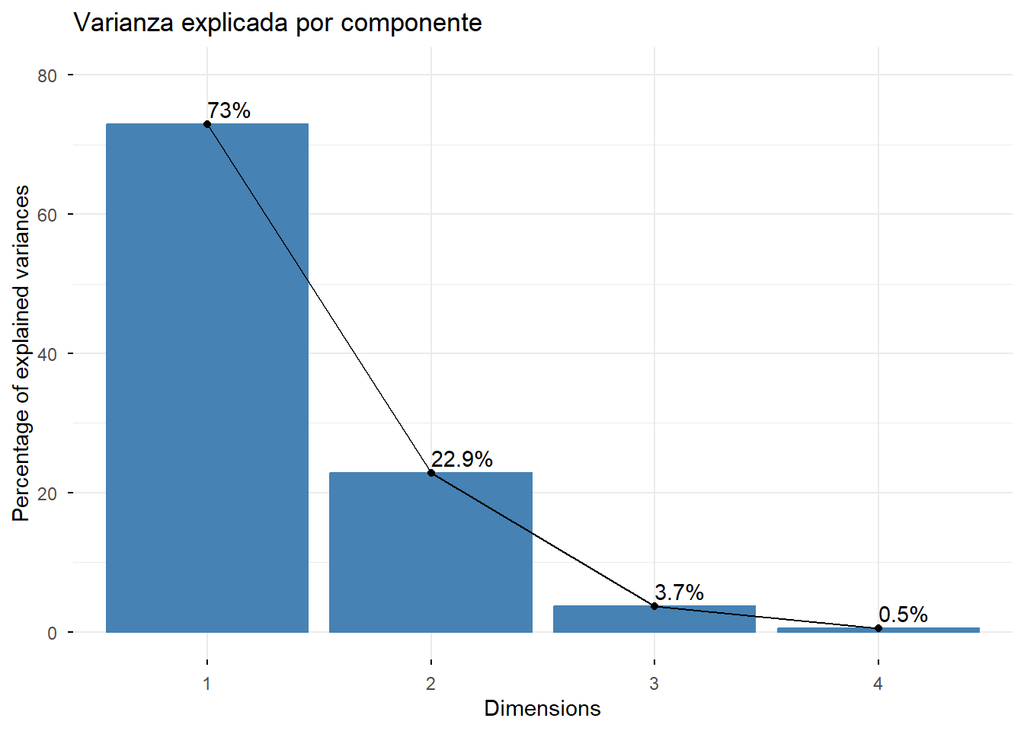

```r
# Visualizar varianza explicada
fviz_eig(pca_result, addlabels = TRUE, ylim = c(0, 80),
         main = "Varianza explicada por componente")
```

**Pregunta**: ¿Cuántas componentes necesitamos para explicar al menos el 90% de la varianza?